# Clustering Analysis on Gene Expressions

Chesie Yu

2/15/2023

**[Clustering analysis](https://scikit-learn.org/stable/modules/clustering.html)** allows us to uncover the **underlying structure embedded in gene expression profiles**: identifying groups of samples sharing similar expression patterns can help **understanding gene functions and disease subtypes**.

*In this notebook, we will perform **clustering on gene expression data to identify patterns associated with various cancer subtypes (BRCA, LUAD, COAD, KIRC, PRAD)**, by applying **$K$-means and hierarchical algorithms** to segment the data into homogenous subgroups. The dataset contains **801 samples** and **20,531 attributes**, representing gene expression levels of patients having different types of tumors. It is part of the [RNA-Seq PANCAN data set](https://www.synapse.org/#!Synapse:syn300013), and can be accessed from [UCI Machine Learning Repository](https://archive.ics.uci.edu/ml/datasets/gene+expression+cancer+RNA-Seq).*

```python
# Import the libraries
import numpy as np
import pandas as pd
import matplotlib.pyplot as plt

from sklearn.cluster import KMeans
from sklearn.cluster import AgglomerativeClustering
from scipy.cluster.hierarchy import linkage, dendrogram
```

## 1. Data Preparation

```python
# Load the genes data
rna = pd.read_csv("data/TCGA-PANCAN-HiSeq-801x20531/data.csv", index_col = 0)

# Print a preview
rna.head(5)
```

|  | gene_0 | gene_1 | gene_2 | gene_3 | gene_4 | gene_5 | gene_6 | gene_7 | gene_8 | gene_9 | ... | gene_20521 | gene_20522 | gene_20523 | gene_20524 | gene_20525 | gene_20526 | gene_20527 | gene_20528 | gene_20529 | gene_20530 |
| --- | --- | --- | --- | --- | --- | --- | --- | --- | --- | --- | --- | --- | --- | --- | --- | --- | --- | --- | --- | --- | --- |
| sample_0 | 0.0 | 2.017209 | 3.265527 | 5.478487 | 10.431999 | 0.0 | 7.175175 | 0.591871 | 0.0 | 0.0 | ... | 4.926711 | 8.210257 | 9.723516 | 7.220030 | 9.119813 | 12.003135 | 9.650743 | 8.921326 | 5.286759 | 0.0 |
| sample_1 | 0.0 | 0.592732 | 1.588421 | 7.586157 | 9.623011 | 0.0 | 6.816049 | 0.000000 | 0.0 | 0.0 | ... | 4.593372 | 7.323865 | 9.740931 | 6.256586 | 8.381612 | 12.674552 | 10.517059 | 9.397854 | 2.094168 | 0.0 |
| sample_2 | 0.0 | 3.511759 | 4.327199 | 6.881787 | 9.870730 | 0.0 | 6.972130 | 0.452595 | 0.0 | 0.0 | ... | 5.125213 | 8.127123 | 10.908640 | 5.401607 | 9.911597 | 9.045255 | 9.788359 | 10.090470 | 1.683023 | 0.0 |
| sample_3 | 0.0 | 3.663618 | 4.507649 | 6.659068 | 10.196184 | 0.0 | 7.843375 | 0.434882 | 0.0 | 0.0 | ... | 6.076566 | 8.792959 | 10.141520 | 8.942805 | 9.601208 | 11.392682 | 9.694814 | 9.684365 | 3.292001 | 0.0 |
| sample_4 | 0.0 | 2.655741 | 2.821547 | 6.539454 | 9.738265 | 0.0 | 6.566967 | 0.360982 | 0.0 | 0.0 | ... | 5.996032 | 8.891425 | 10.373790 | 7.181162 | 9.846910 | 11.922439 | 9.217749 | 9.461191 | 5.110372 | 0.0 |

5 rows × 20531 columns

```python
# Check the dimensions
rna.shape
```

```
(801, 20531)
```

```python
# Check for missings
rna.isna().sum().sum()
```

```
0
```

```python
# Load the label data
tumor = pd.read_csv("data/TCGA-PANCAN-HiSeq-801x20531/labels.csv", index_col = 0)

# Print a preview
tumor.head()
```

|  | Class |
| --- | --- |
| sample_0 | PRAD |
| sample_1 | LUAD |
| sample_2 | PRAD |
| sample_3 | PRAD |
| sample_4 | BRCA |

```python
# Check the dimensions
tumor.shape
```

```
(801, 1)
```

```python
# Check for missings
tumor.isna().sum()
```

```
Class    0
dtype: int64
```

```python
# Extract unique classes
tumor.Class.value_counts()
```

```
Class
BRCA    300
KIRC    146
LUAD    141
PRAD    136
COAD     78
Name: count, dtype: int64
```

```python
# Create the design matrix X
X = rna.values
X[:3]
```

```
array([[ 0.        ,  2.01720929,  3.26552691, ...,  8.92132623,
         5.28675919,  0.        ],
       [ 0.        ,  0.59273209,  1.58842082, ...,  9.39785429,
         2.09416849,  0.        ],
       [ 0.        ,  3.51175898,  4.32719872, ..., 10.09046974,
         1.68302267,  0.        ]])
```

```python
# Create the output labels y
y = tumor["Class"].values
y[:5]
```

```
array(['PRAD', 'LUAD', 'PRAD', 'PRAD', 'BRCA'], dtype=object)
```

## 2. $K$-Means Clustering

*First, we will use **[$K$-means clustering](https://scikit-learn.org/stable/modules/generated/sklearn.cluster.KMeans.html)** to find homogeneous subgroups of tumors among samples, by **partitioning the dataset into desired number of $K$ distinct clusters**.*

*Intuitively, variation will continue to decrease as $K$ increases. But adding more clusters does not necessarily improve clustering quality: it may not be able to capture the true underlying structure of the data. Therefore we need to determine the optimal $K$ using the **elbow method**: by visualizing the losses as a function of $K$, we can identify the elbow point where **adding more clusters will no longer significantly improve clustering performance**.*

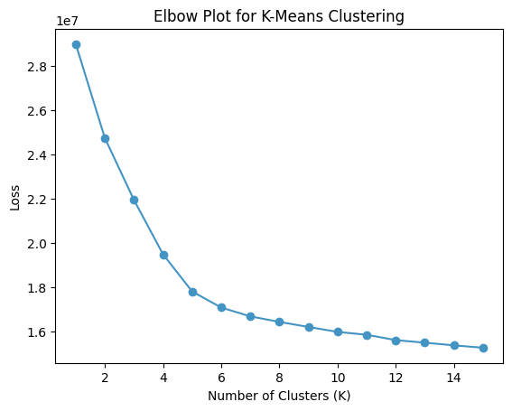

```python
# Create empty list of losses
losses = []

# Create a list of k values
ks = range(1, 16)

# Compute the loss for each k
for k in ks:
    m = KMeans(n_clusters = k, n_init = 20).fit(X)
    losses.append(m.inertia_)

# Create the elbow plot: Plot losses as a function of k
_ = plt.plot(ks, losses, marker = "o", color = "#4393C3")
_ = plt.title("Elbow Plot for K-Means Clustering")
_ = plt.xlabel("Number of Clusters (K)")
_ = plt.ylabel("Loss")
```

*Once the **optimal number of clusters $K = 5$** is identified, we can apply the $K$-means clustering algorithm:*

```python
# Fit K-means clustering with k = 5
m = KMeans(n_clusters = 5, n_init = 50).fit(X)

# Extract the cluster assignments
km_cluster = m.predict(X)
km_cluster[:100]
```

```
array([0, 3, 0, 0, 1, 0, 2, 0, 1, 0, 1, 2, 0, 1, 1, 1, 3, 2, 2, 0, 1, 2,
       3, 1, 2, 3, 4, 1, 1, 1, 1, 1, 2, 1, 0, 1, 2, 3, 1, 1, 2, 0, 0, 2,
       2, 1, 0, 4, 1, 3, 1, 3, 1, 0, 4, 1, 1, 4, 2, 1, 3, 1, 1, 3, 0, 4,
       1, 0, 2, 1, 2, 1, 1, 3, 1, 3, 1, 2, 0, 4, 1, 0, 1, 1, 0, 0, 1, 1,
       2, 1, 0, 0, 1, 1, 1, 0, 4, 1, 0, 1], dtype=int32)
```

```python
# Extract cluster centers
center = m.cluster_centers_
center
```

```
array([[0.02654385, 3.44104073, 3.97126223, ..., 9.69678011, 5.8496973 ,
        0.03572931],
       [0.01128645, 2.83527335, 2.80449053, ..., 9.7851823 , 6.14993228,
        0.06894019],
       [0.04686506, 2.39455662, 2.44209827, ..., 9.43000135, 5.12209056,
        0.12948832],
       [0.04079886, 3.36449552, 3.46238608, ..., 9.36680765, 5.36532371,
        0.20733759],
       [0.02279657, 3.45441244, 3.24426629, ..., 9.35325943, 3.5612111 ,
        0.03325514]])
```

### 2.1 Evaluation

*To evaluate the $K$-means clustering results, we can compute the **inertia**, measured as the sum of squared distances between each data point and its centroid. In general, our objective is to **minimize the within cluster variation $C_k$** so that the elements within a cluster would be as similar as possible.*

```python
# Compute the loss
m.inertia_
```

```
17801949.109766014
```

*However, given the original labels, a better approach would be using **external criteria** to [assess the clustering performance](https://scikit-learn.org/stable/modules/clustering.html#clustering-performance-evaluation). Here we will report the **Adjusted Rand Index (ARI)** and **Normalized Mutual Information (NMI)**.*

**[ARI](https://scikit-learn.org/stable/modules/generated/sklearn.metrics.adjusted_rand_score.html)** measures the **similarity between two assignments within range [-1, 1]**; it is **adjusted for chance** so that random labeling will be assigned an ARI score close to zero

**[NMI](https://scikit-learn.org/stable/modules/generated/sklearn.metrics.normalized_mutual_info_score.html#sklearn.metrics.normalized_mutual_info_score)** is an **information theoretic measure of cluster quality**; it quantifies the shared information between clusterings. NMI ranges from 0 to 1, with 1 indicating perfectly identical assignments and 0 suggesting random assignments with no mutual information.

*As shown below, both ARI and NMI scores are **very close to 1**, indicating a **near perfect match**.*

```python
# Compute ARI and NMI
from sklearn.metrics import adjusted_rand_score, normalized_mutual_info_score
ari = adjusted_rand_score(y, km_cluster)
nmi = normalized_mutual_info_score(y, km_cluster)
print(f"ARI: {ari:.3f}\nNMI: {nmi:.3f}")
```

```
ARI: 0.981
NMI: 0.972
```

```python
# Show the confusion matrix
cm = pd.crosstab(y, km_cluster)
cm
```

| col_0 row_0 | 0 | 1 | 2 | 3 | 4 |
| --- | --- | --- | --- | --- | --- |
| BRCA | 0 | 299 | 0 | 1 | 0 |
| COAD | 0 | 0 | 0 | 2 | 76 |
| KIRC | 0 | 1 | 145 | 0 | 0 |
| LUAD | 0 | 2 | 0 | 139 | 0 |
| PRAD | 136 | 0 | 0 | 0 | 0 |

```python
# # Map the labels to each tumor type
# # Find the most common true label in each predicted cluster
# # (Caveat: only work with the assumption that each true label appears in only one predicted cluster)
# mapping = {i: cm.loc[:, i].idxmax() for i in cm.columns}
# category = [mapping[cl] for cl in km_cluster]

# # Compute accuracy
# from sklearn.metrics import accuracy_score
# accuracy_score(y, category)
```

### 2.2 Visualization

*Clusters formed on high-dimensional data can be hard to visualize. An alternative approach would be to create **a two-dimensional representation of the dataset** using **[Principal Component Analysis (PCA)](https://scikit-learn.org/stable/modules/generated/sklearn.decomposition.PCA.html)**. Through dimensionality reduction, we can **visualize high dimensional clusters using only the two largest components** while still retaining some of the original information: the plot below illustrates **5 distinct clusters** in the data.*

```python
# Import PCA library
from sklearn.decomposition import PCA

# Perform dimensionality reduction
m = PCA(n_components = 2).fit(X)
X_pca = m.transform(X)

# Transform cluster center
center_pca = m.transform(center)
```

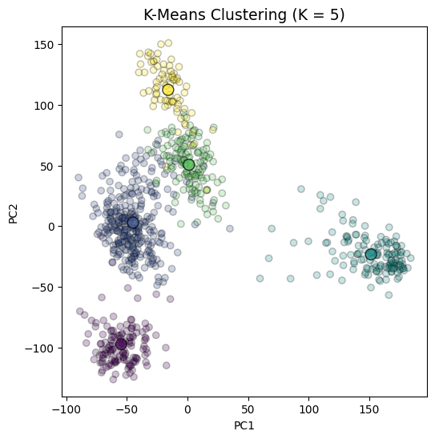

```python
# Visualize the clustering result
fig, ax = plt.subplots(figsize = (6, 6))
ax.scatter(X_pca[:, 0], X_pca[:, 1], c = km_cluster,
               edgecolor = "black", alpha = 0.25)
ax.scatter(center_pca[:, 0], center_pca[:, 1], c = np.unique(km_cluster),
            s = 100, alpha = 0.75, edgecolor = "black")
ax.set_aspect("equal")
ax.set_title("K-Means Clustering (K = 5)", size = 13.5)
ax.set_xlabel("PC1")
ax.set_ylabel("PC2")
plt.show()
```

*Alternatively, we can visualize multivariate numerical data using a **parallel coordinate plot**: the variables are represented by axes placed parallel to each other while the observations are plotted as lines connected across all axes.*

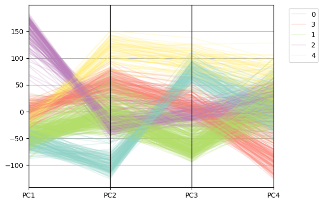

```python
# Perform dimensionality reduction
m = PCA(n_components = 4).fit(X)
X_pca = m.transform(X)

# Add the cluster number to components
X_pca_cluster = pd.DataFrame(X_pca, columns = ["PC1", "PC2", "PC3", "PC4"])
X_pca_cluster["cluster"] = km_cluster

# Display parallel coordinates plots to compare the features
pd.plotting.parallel_coordinates(X_pca_cluster, "cluster",
                                 colormap = plt.get_cmap("Set3"), alpha = 0.2)
plt.legend(bbox_to_anchor = (1.05, 1), loc = "upper left")
plt.show()
```

## 3. Hierarchical Clustering

*Now we will implement **[hierarchical clustering](https://scikit-learn.org/stable/modules/generated/sklearn.cluster.AgglomerativeClustering.html)** on the gene expression data using various linkages: **complete, average, and single**. This method uses a **bottom-up agglomerative** approach by fusing similar observations into branches; the earlier the fusion occurs, the more similar the observations are. By fusing the genes that are close to each other, we will form a hierarchical representation of the clusters.*

```python
# Specify the linkage methods
linkage_methods = ["complete", "average", "single"]

# Perform hierarchical clustering with different linkages
hc_cluster = {}
for method in linkage_methods:
    hc_cluster[method] = AgglomerativeClustering(n_clusters = 5, linkage = method).fit_predict(X)
{key: value[:10] for key, value in hc_cluster.items()}
```

```
{'complete': array([4, 3, 1, 4, 1, 4, 0, 4, 1, 4]),
 'average': array([0, 0, 2, 0, 0, 0, 0, 0, 0, 0]),
 'single': array([0, 0, 0, 0, 0, 0, 0, 0, 0, 0])}
```

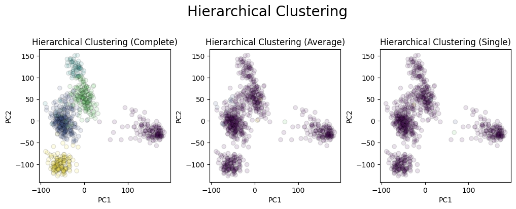

```python
# Set up the subplots
fig, axs = plt.subplots(1, len(linkage_methods), figsize = (12, 4.5))

# Plot the clustering results
for i, method in enumerate(linkage_methods):
    ax = plt.subplot(1, 3, i + 1)
    ax.scatter(X_pca[:, 0], X_pca[:, 1], c = hc_cluster[method],
                   edgecolor = "black", alpha = 0.12)
    ax.set_aspect("equal")
    ax.set_title(f"Hierarchical Clustering ({method.capitalize()})")
    ax.set_xlabel("PC1")
    ax.set_ylabel("PC2")

# Display the plot
fig.subplots_adjust(wspace = 0.3)
fig.suptitle("Hierarchical Clustering", size = 20)
plt.show()
```

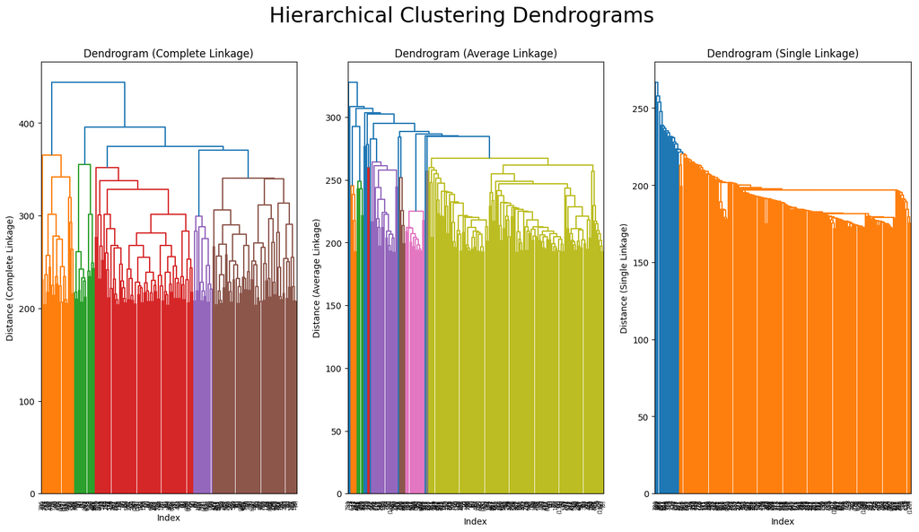

```python
# Set up the subplots
fig, axs = plt.subplots(1, len(linkage_methods), figsize = (18, 9))
colors = ["#2166AC", "#4393C3", "#92C5DE", "#D1E5F0", "#FDDBC7", "#F4A582", "#D6604D", "#B2182B"]

# Visualize each linkage method
for i, method in enumerate(linkage_methods):
    # Create the linkage matrix
    Z = linkage(X, method)
    # Create the dendrogram
    dendrogram(Z, ax = axs[i], color_threshold = 0.83 * max(Z[:, 2]),
               p = 200, truncate_mode = "lastp",
               leaf_font_size = 6, leaf_rotation = 90)
    axs[i].set_title(f"Dendrogram ({method.capitalize()} Linkage)")
    axs[i].set_xlabel("Index")
    axs[i].set_ylabel(f"Distance ({method.capitalize()} Linkage)")

# Display the plot
fig.suptitle("Hierarchical Clustering Dendrograms", size = 24)
plt.show()
```

```python
# Compute ARI and NMI
for m in hc_cluster:
    ari = adjusted_rand_score(y, hc_cluster[m])
    nmi = normalized_mutual_info_score(y, hc_cluster[m])
    print(f"{m.capitalize()} Linkage:\nARI: {ari:.3f}\nNMI: {nmi:.3f}\n")
```

```
Complete Linkage:
ARI: 0.849
NMI: 0.856

Average Linkage:
ARI: -0.008
NMI: 0.023

Single Linkage:
ARI: 0.000
NMI: 0.010
```

*Result shows that **$K$-means clustering produces a partition that closely aligns with the underlying structure in the data**. Both the ARI and NMI are very close to 1, suggesting that the clusters are well represented.*

*On the other hand, **hierarchical clustering yielded lower performance**. Among the three linkage methods tested, **complete linkage performed fairly well with ARI and NMI greater than 0.8**, capturing some of the cluster structure. However, clustering based on **average and single linkage provided less than satisfactory results**: almost all genes are grouped into the same cluster.*

*This result **aligns with the findings in numerous comparative studies on gene expression clusterings**: $K$-means tends to "outperform hierarchical clustering"$^{[1]}$; "single linkage presents the worse results"$^{[2]}$ within the class of hierarchical methods.*

*[1] D'haeseleer, P. How does gene expression clustering work?. Nat Biotechnol 23, 1499–1501 (2005). https://doi.org/10.1038/nbt1205-1499*

*[2] de Souto, M.C., Costa, I.G., de Araujo, D.S. et al. Clustering cancer gene expression data: a comparative study. BMC Bioinformatics 9, 497 (2008). https://doi.org/10.1186/1471-2105-9-497*

### Limitations

*There are several limitations with the two clustering methods. Clustering results are **sensitive to outliers and noise in the data**; the clusters may not be as representative with the presence of outliers. **Without knowing the ground truth**, model evaluation is often limited to using dissimilarity measurements for internal validation.*

*In $K$-means clustering, the **result will vary with our choice of number of clusters**, and this decision is relatively subjective even with the help from elbow plots. Moreover, $K$-means clustering is sensitive to initial conditions: **different initializations can lead to different results**, and it could therefore converge to a local optimum instead of global optimum.*

*For hierarchical clustering, **our choice of linkage method can have significant impacts on the results**. Just as the case above, single and average linkages may yield significantly worse results with highly imbalanced classes. Hierarchical clustering is also conducted based on **local decisions**: it merges the most compact cluster available at each step, therefore would **result in a potentially suboptimal solution**.*

### Future Work

```python
# PCA + Kmeans
```

```python
# %%timeit -r 2 -n 2
# Perform dimensionality reduction
X_pca = PCA(n_components = 7).fit_transform(X)

# Fit K-means clustering with k = 5
m = KMeans(n_clusters = 5, n_init = 50).fit(X_pca)

# Extract the cluster assignments
km_cluster = m.predict(X_pca)
km_cluster[:100]
```

[output not shown]

```python
# Compute the loss
m.inertia_
```

[output not shown]

```python
# Compute ARI and NMI
ari = adjusted_rand_score(y, km_cluster)
nmi = normalized_mutual_info_score(y, km_cluster)
print(f"ARI: {ari:.3f}\nNMI: {nmi:.3f}")
```

[output not shown]

```python
pd.crosstab(y, km_cluster)
```

[output not shown]

```python
# Create empty list of ARI and NMI
ari = []
nmi = []

# Create a list of n_component values
n_components = range(1, 50)

# Compute the loss for each k
for nc in n_components:
    # Fit PCA
    X_pca = PCA(n_components = nc).fit_transform(X)
    # Fit K-means clustering and extract the cluster assignments
    km_cluster = KMeans(n_clusters = 5, n_init = 50).fit_predict(X_pca)
    # Record ARI and NMI
    ari.append(adjusted_rand_score(y, km_cluster))
    nmi.append(normalized_mutual_info_score(y, km_cluster))

# Plot number of components against each metric
_ = plt.plot(n_components, ari, marker = "o", color = "#4393C3")
_ = plt.plot(n_components, nmi, marker = "o", color = "#A51F13")
_ = plt.title("PCA Results")
_ = plt.xlabel("Number of Components")
_ = plt.ylabel("Metric")
_ = plt.ylim(ymin = 0)
```

[output not shown]

```python
## Feature Scaling
```

```python
# Z-Score Normalization / Standardization
Xs = (X - X.mean(axis = 0)) / X.std(axis = 0)

# Set nan to zeros (267 features contains all zeros)
Xs[np.isnan(Xs)] = 0
```

```python
# Min-Max Scaling / Normalization
Xn = (X - X.min(axis = 0)) / (X.max(axis = 0) - X.min(axis = 0))

# Set nan to zeros (267 features contains all zeros)
Xn[np.isnan(Xn)] = 0

# from sklearn.preprocessing import MinMaxScaler
# Xn = MinMaxScaler().fit_transform(X)
```

```python
# Fit K-means clustering with k = 5
m = KMeans(n_clusters = 5, n_init = 50).fit(Xs)

# Extract the cluster assignments
km_cluster = m.predict(Xs)
km_cluster[:100]
```

[output not shown]

```python
# Extract cluster centers
center = m.cluster_centers_
center
```

[output not shown]

```python
m.inertia_
```

[output not shown]

```python
# Compute ARI and NMI
ari = adjusted_rand_score(y, km_cluster)
nmi = normalized_mutual_info_score(y, km_cluster)
print(f"ARI: {ari:.3f}\nNMI: {nmi:.3f}")
```

[output not shown]

```python
pd.crosstab(y, km_cluster)
```

[output not shown]

```python
# Perform dimensionality reduction
m = PCA(n_components = 2).fit(Xs)
Xs_pca = m.transform(Xs)

# Transform cluster center
center_pca = m.transform(center)
```

```python
# Visualize the clustering result
fig, ax = plt.subplots(figsize = (6, 6))
ax.scatter(Xs_pca[:, 0], Xs_pca[:, 1], c = km_cluster,
               edgecolor = "black", alpha = 0.25)
ax.scatter(center_pca[:, 0], center_pca[:, 1], c = np.unique(km_cluster),
            s = 100, alpha = 0.75, edgecolor = "black")
ax.set_aspect("equal")
ax.set_title("K-Means Clustering (K = 5)", size = 13.5)
ax.set_xlabel("PC1")
ax.set_ylabel("PC2")
plt.show()
```

[output not shown]